# Fitness_tracker_project1

Ryan King

12/4/2021

### Project 1: Fitness tracker

## Load the data and environment

```r
library(dplyr)
```

```r
library(ggplot2)
library(data.table)
library(stringr)
file_path <- "C:/Users/I0485672/Downloads/activity.csv"
data <- read.csv(file_path)
```

## Analyzing the data

There are some NA’s in here. They will be removed until imputed step. Why? They don’t have the device on or working. We cannot say that means zero steps.

# Let’s look at the total number of steps taken each day

```r
data_summary <- data[complete.cases(data), ] %>% group_by(date) %>% summarize(mean=sum(steps, na.rm = TRUE))
data_summary
```

```
## # A tibble: 53 x 2
##    date        mean
##    <chr>      <int>
##  1 2012-10-02   126
##  2 2012-10-03 11352
##  3 2012-10-04 12116
##  4 2012-10-05 13294
##  5 2012-10-06 15420
##  6 2012-10-07 11015
##  7 2012-10-09 12811
##  8 2012-10-10  9900
##  9 2012-10-11 10304
## 10 2012-10-12 17382
## # ... with 43 more rows
```

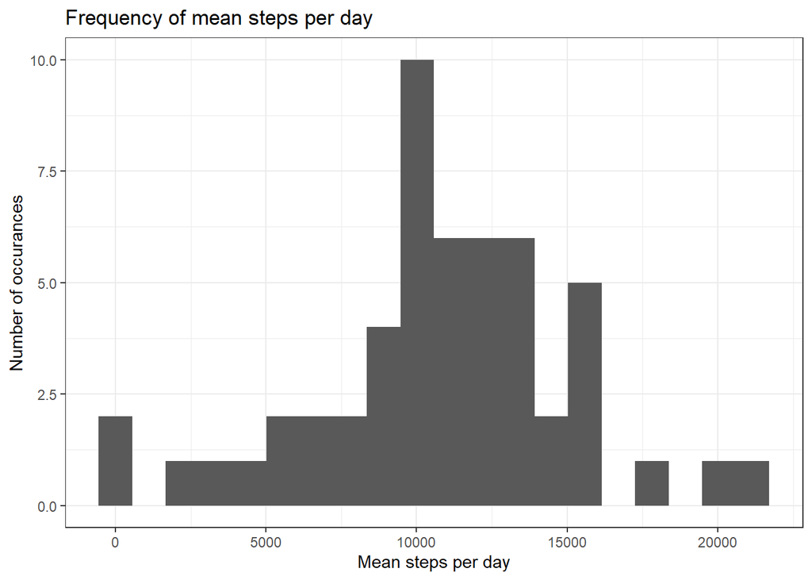

```r
data_summary %>% ggplot(aes(x = mean)) + geom_histogram(bins = 20) +
  theme_bw() + labs(x='Mean steps per day', y='Number of occurances',
                    title = 'Frequency of mean steps per day')
```

# let’s look at the mean and steps per day.

```r
data_summary <-  data[complete.cases(data), ] %>% group_by(date) %>% summarize(StepsSum=sum(steps, na.rm = TRUE))
mean(data_summary$StepsSum)
```

```
## [1] 10766.19
```

```r
median(data_summary$StepsSum)
```

```
## [1] 10765
```

What’s the max steps in a given interval?

```r
data_summary.max <-  data[complete.cases(data), ] %>% group_by(interval) %>% summarize(StepsMax=max(steps, na.rm = TRUE))
tophit <- data_summary.max %>% arrange(desc(StepsMax)) %>% head(n=1)
tophit
```

```
## # A tibble: 1 x 2
##   interval StepsMax
##      <int>    <int>
## 1      615      806
```

The 615 interval has the max steps

But that’s max… what’s the max (highest) average steps taken

```r
data_summary <-  data[complete.cases(data), ] %>% group_by(interval) %>% summarize(mean=mean(steps, na.rm = TRUE))
data_summary %>% arrange(desc(mean))
```

```
## # A tibble: 288 x 2
##    interval  mean
##       <int> <dbl>
##  1      835  206.
##  2      840  196.
##  3      850  183.
##  4      845  180.
##  5      830  177.
##  6      820  171.
##  7      855  167.
##  8      815  158.
##  9      825  155.
## 10      900  143.
## # ... with 278 more rows
```

```r
max.avg.results <- data_summary %>% arrange(desc(mean)) %>% head(n=1)
print(paste("The largest interval is,", max.avg.results$interval, "with", max.avg.results$mean, "max steps on average"))
```

```
## [1] "The largest interval is, 835 with 206.169811320755 max steps on average"
```

The largest interval is, 835 with 206.169811320755 max steps on average

## let’s look at a time series

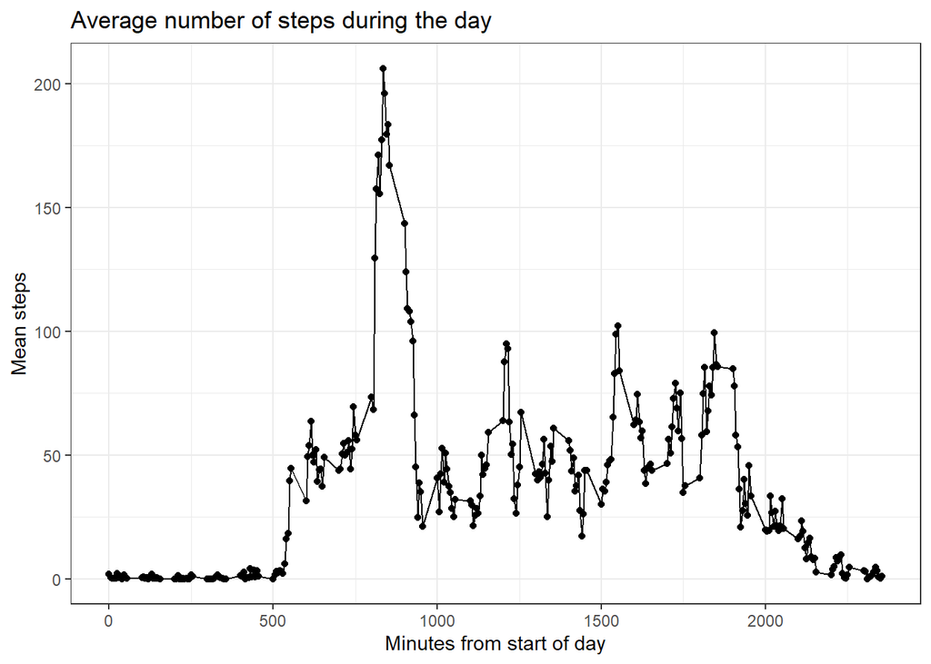

```r
data_summary <-  data[complete.cases(data), ] %>% group_by(interval) %>% summarize(mean=mean(steps, na.rm = TRUE))

ggplot(data_summary, aes(x = interval, y = mean)) +
  geom_point() + geom_line() + theme_bw() +
  labs(y="Mean steps", x = "Minutes from start of day",
       title = "Average number of steps during the day")
```

## Imputing data

How to impute data? There’s many many theories out there 1. mean - on each interval 2. nearest neighbor - for example, steps on a Saturday vs. Monday and take mean 3. So much more, but #2 is really good.

Let’s do the mean of the days of the week for the given interval If you really wanted a nice imputation, perhaps a lagging average?

```r
data.avg.per.weekday <- data
data.avg.per.weekday$date <- as.Date(data$date) %>% weekdays()
data.avg.per.weekday <-  data.avg.per.weekday[complete.cases(data.avg.per.weekday), ] %>% group_by(date, interval) %>% summarize(mean=mean(steps, na.rm = TRUE))
data.meanImpute <- data
for (i in 1:nrow(data.meanImpute)){
  if(is.na(data.meanImpute[i, 1])){
    data.meanImpute[i, 1] <- data.avg.per.weekday %>%
      filter(date == weekdays(as.Date(data[i, 2])) & interval == data[i, 3]) %>%
      .[[3]]
  }
}

print("Checking data:")
```

```
## [1] "Checking data:"
```

```r
any(is.na(data.meanImpute))
```

```
## [1] FALSE
```

```r
# cha-ching
```

### Visualizing imputed data

Let’s make a histogram of the total number of steps taken each day after missing values are imputed

[figure not shown]

```r
data.check <- data.meanImpute %>% group_by(date) %>% summarize(DailySteps = sum(steps))

data.check %>% ggplot(aes(x = DailySteps)) +
geom_histogram() + theme_bw() +
  labs(y="Days with number of steps", x = "Daily steps",
       title = "Average number of steps during the day")
```

Let’s use this for a days of the week plot

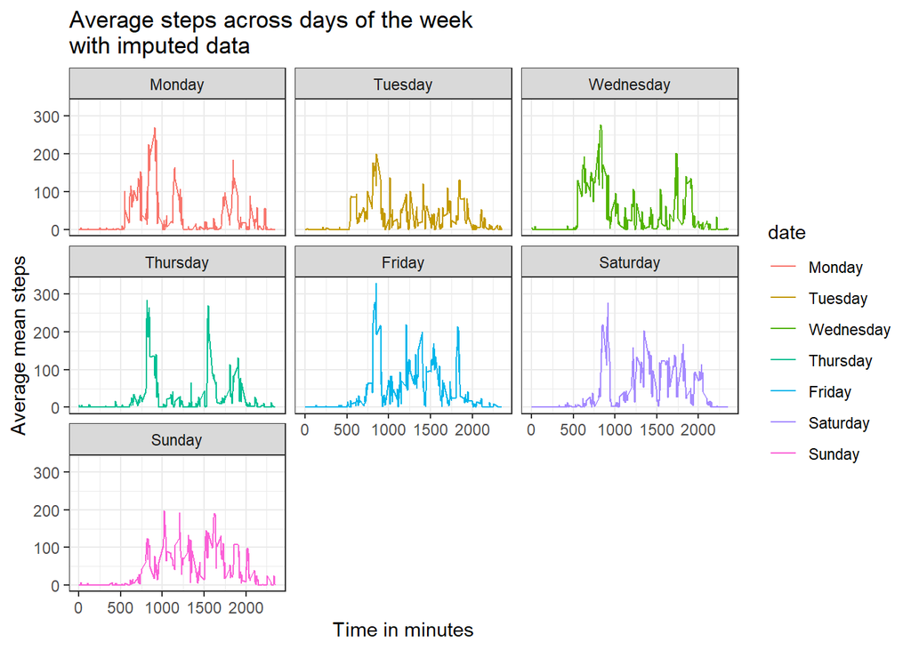

```r
# let's get the days of the week reordered properly for the graph
data.meanImpute$date <- weekdays(as.Date(data.meanImpute$date))
data.meanImpute$date <- factor(data.meanImpute$date, levels =
                                    c("Monday", "Tuesday", "Wednesday",
                                      "Thursday", "Friday", "Saturday",
                                      "Sunday"))

data.meanImpute.eachday <- data.meanImpute %>% group_by(date, interval) %>% summarise(meanSteps = mean(steps))
data.meanImpute.eachday %>% ggplot(aes(x = interval, y = meanSteps, color = date)) +
  geom_line() + theme_bw() + facet_wrap(~date) +
  labs(title = "Average steps across days of the week\nwith imputed data",
       x = "Time in minutes", y = "Average mean steps")
```

They may want weekdays VS weekends, not all days.

```r
data.meanImpute$date <- str_replace(data.meanImpute$date, "Saturday", "Weekend")
data.meanImpute$date <- str_replace(data.meanImpute$date, "Sunday", "Weekend")
data.meanImpute$date <- if_else(data.meanImpute$date == 'Weekend', 'Weekend', 'Weekday')
data.meanImpute.final <- data.meanImpute %>% group_by(date, interval) %>% summarise(meanSteps = mean(steps))
```

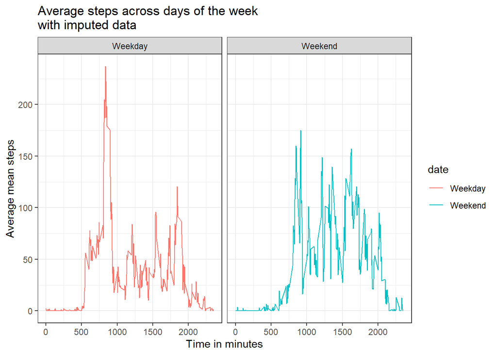

```r
data.meanImpute.final %>% ggplot(aes(x = interval, y = meanSteps, color = date)) +
  geom_line() + theme_bw() + facet_wrap(~date) +
  labs(title = "Average steps across days of the week\nwith imputed data",
       x = "Time in minutes", y = "Average mean steps")
```